# Part II - (Data Analysis and Visualization of Cats)

## by (Seyada Shaer )

## Investigation Overview

> The purpose of this project is to analyze a dataset of cats, focusing on key features such as age, weight, breed, and gender. The goal is to uncover trends, distributions, and relationships that are meaningful for understanding characteristics across different cat breeds.

## Dataset Overview

> > The dataset contains information about cats, including variables like age (in years), weight (in kg), breed, and gender. It provides a comprehensive overview of these features across multiple breeds, allowing for univariate, bivariate, and multivariate analyses. The data is clean and suitable for immediate analysis with minimal preprocessing required.

## (Visualization 1: Age Distribution)

> This visualization explores the age distribution across all cats in the dataset. It helps identify the most common age ranges and provides insights into the lifespan of various breeds.

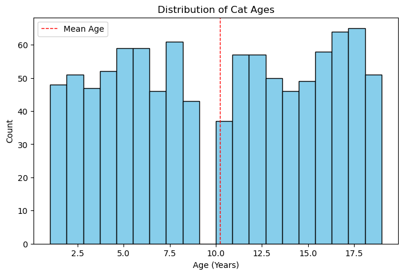

## (Visualization 2) Age and Weight

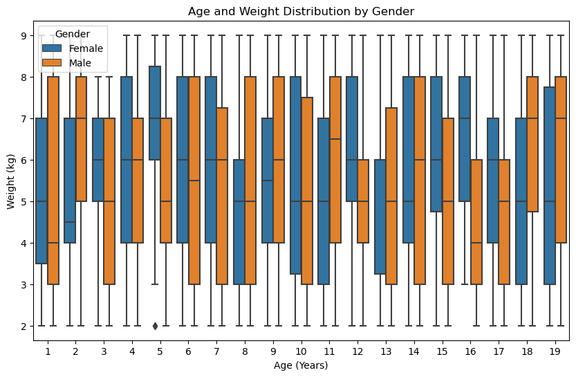

## (Visualization 3) Age distribution across Breeds and Genders

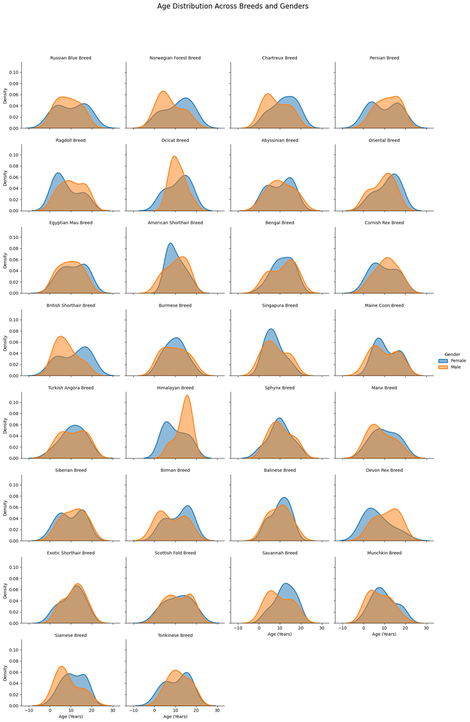